# **Lab 4: SAS Macro and Report Examples**

Biostatistics 203A

October 28, 2023

In this lab, you will be introduced to the SAS macro language. Macros are useful if you want to make your SAS programs more flexible and to allow them to be used in different situations without having to rewrite entire programs. You will also be introduced to the *output delivery system* and `proc report`, two useful tools that are often used in conjunction with SAS macros.

A pdf file containing your name, your UID number, and your responses to each of the items below labeled *Exercise* should be submitted via BruinLearn prior to 5:00PM on November 7th. This assignment will be graded on a scale from 0-20 and will count toward the homework component of your course grade.

## Macro Variables

When a SAS program is submitted, before SAS compiles the code, SAS scans the program for the existence of ampersands (`&`) or percentage signs (`%`). If SAS encounters either or both of these two symbols, SAS calls in the macro processor. You can envision the macro processor as a find-and-replace tool similar to those found in word processors.

Variables starting with `&` are called **macro variables**. The macro processor finds these variables and replaces them with text values.

## SAS Macros

Macros make use of macro variables. Macros can be entire SAS programs or just pieces of SAS code. A SAS macro is defined using the following format.

```
%MACRO macroname(argument1, argument2, . . . );
   SAS code;
%MEND macroname;
```

Once a macro has been defined by executing the program above, it can be called using a statement in the following format:

```
%macroname(argument1 = x, argument2 = 7, . . . )
```

All macro-calling statements consist of a percentage sign (`%`) followed by the macro name, and the values that you want to substitute for the arguments within parentheses.

Let’s define and call a simple macro.

```
%MACRO gen(n,Start,End);
 data generate;
  do Subj = 1 to &n;
   x = int((&End - &Start + 1)*ranuni(0) + &Start);
   output;
  end;
 run;
 proc print data=generate noobs;
  title "Randomly Generated Data Set with &n Observations";
  title2 "Values are Integers from &Start to &End";
 run;
%MEND;
```

```
%gen(4,1,100);
```

This program is general enough to allow you to change the number of random numbers you would like to generate as well as the starting and ending values of the numbers being generated.

We refer to `n`, `Start` and `End` as positional arguments. As with R functions, you could have specified the following:

```
%gen(n = 4, Start = 1, End = 100);
```

but using the argument names is not necessary and if they are not provided, SAS assumes that you provided arguments in the same order as specified when defining the macro.

**Exercise 1:**

Rewrite the following program as a macro. Let the starting and ending values of the DO loop be positional arguments within the macro. Call the macro for a starting value of 10 and an ending value of 15. Make sure the title generated along with the `proc print` output is correct.

```
data sqr_table;
 do n = 1 to 5;
  Sqr_n = n*n;
  output;
 end;
run;
title "Table of Squared Values for Integers from 1 to 5";
proc print data=sqr_table noobs;
run;
```

Paste your SAS code (containing the macro definition and call statement) and output into the file you submit.

## Using Macros to Generate Tables

Let’s return to the Los Angeles Physician data set (`cms_providers_la.sas7bdat`). Suppose we would like to use `proc tabulate` to generate means and standard deviations for the variables *Average Age of Beneficiaries* and *Average HCC Risk Score of Beneficiaries*. (HCC or Hierarchical Condition Category is a patient-level risk categorization that is used by CMS to adjust health plan payments). We could use the following SAS program.

```
libname L "C:\\Users\\haralis\\Documents\\BIOSTAT 203A\\Data";
```

```
title "Beneficiary Age and Risk by Provider Type";
proc tabulate data=L.cms_providers_la;
 class provider_type;
 var beneficiary_average_age beneficiary_average_risk_score;
 table provider_type='',
       (beneficiary_average_age beneficiary_average_risk_score)*
       (n='N' mean='Mean' std='Standard Deviation');
run;
```

This creates exactly the table we were interested in, information on all provider types in a single table. However, what if your job was to generate tables such as this for categories of provider types? It would be tedious to copy, paste, edit, and execute programs such as the following for each group (note that we simply added a `where` statement).

```
title "Beneficiary Age and Risk by Provider Type";
proc tabulate data=L.cms_providers_la;
 where provider_type contains "Neur";
 class provider_type;
 var beneficiary_average_age beneficiary_average_risk_score;
 table provider_type='',
       (beneficiary_average_age beneficiary_average_risk_score)*
       (n='N' mean='Mean' std='Standard Deviation');
run;
```

This is where macros come in handy. We can simply house this program within a macro which is allowed to take different values in the `where` statement. We do this as follows:

```
%MACRO provtyp(string);
title "Beneficiary Age and Risk by Provider Type";
proc tabulate data=L.cms_providers_la;
 where provider_type contains &string;
 class provider_type;
 var beneficiary_average_age beneficiary_average_risk_score;
 table provider_type='',
       (beneficiary_average_age beneficiary_average_risk_score)*
       (n='N' mean='Mean' std='Standard Deviation');
run;
%MEND;
```

```
%provtyp("Neur")
```

```
%provtyp("Psych")
```

This allows us the flexibility to identify groups of providers based on portions of text matched to values in the provider type variable. We could also specify the entire provider name (i.e. *Internal Medicine*) to get statistics for that single provider type.

**Exercise 2**

Using `proc tabulate`, create a SAS macro that recreates the table below. The columns labeled *Provider Type 1* and *Provider Type 2* should correspond to positional arguments accepted by the macro. The macro will thus take two arguments that will list values within the `provider_type` variable that will determine the data displayed within the two columns.

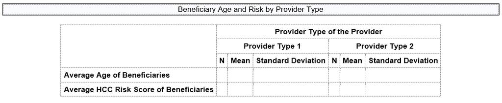

After creating the macro, call it using the positional arguments *Anesthesiology* and *Orthopedic Surgery*. Paste your SAS code (containing the macro definition and call statement) and table output into the file you submit.

## The Output Delivery System

The Output Delivery System (ODS) refers to the system that sends output objects generated when SAS procedures are ran to destinations such as HTML, RTF, PDF, and even SAS data sets. The ODS also allows you to customize the output object’s fonts, colors, size, and layout. We have actually already used the ODS functionality of SAS to output the results of `proc freq` or `proc means` to SAS data sets. We will now demonstrate sending output to an HTML file and then to an RTF file. We have been copying and pasting our results from the *Results Viewer* directly into a word document or other file. It is often preferable to generate output files directly.

Sending SAS output to an HTML file requires only two additional statements between which your SAS program is placed.

```
ods html file = 'C:\Path\sampleoutput.html';
 SAS Program;
ods html close;
```

Let’s try it out (be sure to replace the `file = option` below to specify a path on your local machine or drive):

```
ods html file = 'C:\\Users\\haralis\\Documents\\BIOSTAT 203A\\Output\\sampleoutput.html';
```

```
title "Listing of Physicians";
proc print data=L.cms_providers_la (obs=5);
 id npi;
 var nppes_provider_last_org_name nppes_provider_first_name;
run;

title "Total Services by Provider Gender";
proc means data=L.cms_providers_la;
 class nppes_provider_gender;
 var total_services;
run;
ods html close;
```

You can find your html file at the location you specified in the `file = option`. Although there exists great flexibility in being able to customize the appearance of ODS output, it can take a lot of time and effort. Luckily, there are built-in styles that change the appearance of the output without much work on your part. Styles are specified using an option on the first `ods` statement. For instance, let’s replace the first statement above with the statement below and re-run the program.

```
ods html file = 'C:\\Users\\haralis\\Documents\\BIOSTAT 203A\\Output\\sampleoutput.html' style=FancyPrinter;
```

```
ods html file = 'C:\\Users\\haralis\\Documents\\BIOSTAT 203A\\Output\\sampleoutput.html' style=FancyPrinter;

title "Listing of Physicians";
proc print data=L.cms_providers_la (obs=5);
 id npi;
 var nppes_provider_last_org_name nppes_provider_first_name;
run;

title "Total Services by Provider Gender";
proc means data=L.cms_providers_la;
 class nppes_provider_gender;
 var total_services;
run;
ods html close;
```

Other built-in styles available for use can be accessed by selecting Tools –> Options –> Preferences –> and then selecting the *Results* tab and the *Styles* menu. One of my favorite styles is `Journal`.

We can also use ODS to create RTF files (rich text format) or PDF (portable document format) files, which are readable with Adobe Reader and Microsoft Word (for RTF files). This is done by simply substituting the word `HTML` with the words `RTF` or `PDF` in the statements and file extensions.

Try running the previously executed program to output an RTF file instead of an HTML file.

```
ods rtf file = 'C:\\Users\\haralis\\Documents\\BIOSTAT 203A\\Output\\sampleoutput2.rtf' style=Journal;

title "Listing of Physicians";
proc print data=L.cms_providers_la (obs=5);
 id npi;
 var nppes_provider_last_org_name nppes_provider_first_name;
run;

title "Total Services by Provider Gender";
proc means data=L.cms_providers_la;
 class nppes_provider_gender;
 var total_services;
run;
ods rtf close;
```

```
proc contents data=L.cms_providers_la;
run;
```

**Exercise 3:**

Rewrite the program above but place it within a macro. Let the macro take positional arguments for:

1. the number of observations to be printed in the `proc print` procedure AND
2. the variable for which gender-specific means will be calculated in the `proc means` procedure

Call the macro for respective positional arguments of `10` and `beneficiary_average_risk_score`. Make sure the title generated along with the `proc means` output is appropriate and reflects the two arguments being provided.

(Hint: the `ods rtf` statements can simply be placed inside the `%MACRO` and `%MEND` statements).

Paste your SAS code (containing the macro definition and call statement) into the file you submit. For this exercise, you do *not* need to copy and paste any results into the file you submit.

Using the ODS to output objects from within macros can be very useful.

Let’s return to the macro we developed previously that could be used to generate means and standard deviations for the variables *Average Age of Beneficiaries* and *Average HCC Risk Score of Beneficiaries* among provider type groups.

What if you wanted to create these tables for 20 different provider type groups and to distribute these tables to a different point-of-contact for each of these groups. You would want to call the macro 20 times using different arguments each time. You would also want to generate 20 different output files to be separately distributed. What if we add a second argument to the macro that will allow the output file names to differ across executions of the code?

This could work. Try running the following.

```
%MACRO provtypo(string, name);

ods rtf file = "C:\\Users\\haralis\\Documents\\BIOSTAT 203A\\Output\\&name_output.rtf" style = journal;

title "Beneficiary Age and Risk by Provider Type";
proc tabulate data=L.cms_providers_la;
 where provider_type contains &string;
 class provider_type;
 var beneficiary_average_age beneficiary_average_risk_score;
 table provider_type='',
       (beneficiary_average_age beneficiary_average_risk_score)*
       (n='N' mean='Mean' std='Standard Deviation');
run;
ods rtf close;

%MEND;
```

```
%provtypo("Neur",Neuro Providers);
```

Although the macro executed without any errors, the output file is named `&name_output.rtf`. This is not what we intended.

The SAS macro processor must figure out where our macro variables **start** and **end**. If the macro variable you are using is followed by a character that is not valid in a SAS variable name (such as a space or `/`), it is apparent to the SAS macro processor that the macro variable ends prior to that character.

However, when the macro variable is immediately followed by a character that could be part of a valid variable name, SAS does not end the macro variable. In the above example, SAS assumes the macro variable name is `&name_output`, which is not identified and thus left as-is in the file name. To correct this behavior, we can add a period (`.`) to indicate to the SAS macro processor where a macro variable ends. Let’s replace the first `ods rtf` statement in the above program with the statement below and re-execute the macro.

```
ods rtf file = "C:\\Users\\haralis\\Documents\\BIOSTAT 203A\\Output\\&name._output.rtf" style = journal;
```

```
%MACRO provtypo(string, name);

ods rtf file = "C:\\Users\\haralis\\Documents\\BIOSTAT 203A\\Output\\&name._output.rtf" style = journal;

title "Beneficiary Age and Risk by Provider Type";
proc tabulate data=L.cms_providers_la;
 where provider_type contains &string;
 class provider_type;
 var beneficiary_average_age beneficiary_average_risk_score;
 table provider_type='',
       (beneficiary_average_age beneficiary_average_risk_score)*
       (n='N' mean='Mean' std='Standard Deviation');
run;
ods rtf close;

%MEND;
```

```
%provtypo("Medicine",Medicine Providers)
```

We have solved the problem and can now output our 20 different provider group tables.

**Note:** when specifying macro variables within quoted strings, such as file locations, the quoted strings must use double quotes. This is one of the relatively few instances in which the use of double versus single quotes matters to SAS!

**Exercise 4:**

Edit the program you wrote in Exercise 3 to output to RTF files with different names. Let the file names contain information about the variable used as the second positional argument. To do this, create a third positional argument called `name`.

Call the macro for respective positional arguments of `8`, `beneficiary_average_age`, and `Beneficiary Mean Age`. Paste your SAS code (containing the macro definition and call statement) into the file you submit. For this exercise, you do *not* need to copy and paste any results into the file you submit.

## Generating Reports

We have just demonstrated generating customized output in tabular format using procedures like `proc means`, `proc freq`, and `proc tabulate`. However, often times when generating customized output, you are interested in reports rather than tables.

Reports typically contain detailed, observation-level information, but may also be supplemented with summary information. Let’s explore some of the features of `proc report`.

In its most basic usage, `proc report` is a more customizable version of `proc print`.

A `column` statement is used to select which variables you would like to include in your report and the order in which you would like them to appear.

```
title "Provider Details: Los Angeles";
proc report data=L.cms_providers_la (obs = 5);
 column npi nppes_provider_last_org_name nppes_provider_first_name
        nppes_credentials nppes_provider_gender provider_type;
run;
```

By default, `proc report` produces detail reports for character variables (like the one shown above) and summary reports for numeric variables. If you specify a mix of both types of variables, SAS produces a detail report by default.

To control this behavior, use `define` statements. Here is the default report using numeric variables without a `define` statement. It results in the sum of all average ages of beneficiaries and the sum of all average HCC risk scores for beneficiaries (across the first 5 observations).

```
proc report data=L.cms_providers_la (obs = 5);
 column beneficiary_average_age beneficiary_average_risk_score;
run;
```

If we would prefer the detailed data be displayed for these numeric variables, we can use `define` statements with the `display` option specified.

```
proc report data=L.cms_providers_la (obs = 5);
 column beneficiary_average_age beneficiary_average_risk_score;
 define beneficiary_average_age/display;
 define beneficiary_average_risk_score/display;
run;
```

For each `define` statement in a `proc report` program, SAS will determine whether the variable listed should be displayed at the detail-level or the summary-level. SAS either uses defaults (detail-level for character variables and summary-level for numeric variables), or accepts keywords specified as options:

`display` – detail-level

`analysis` – summary-level

Additionally, the `group` option can be specified in a `define` statement to instruct SAS to calculate summary statistics by `group` for the character variable in the `define` statement.

For instance, the following program will calculate mean *Average Age of Beneficiaries* and *Average HCC Risk Score of Beneficiaries* by Provider Type.

```
proc report data=L.cms_providers_la;
 column provider_type beneficiary_average_age beneficiary_average_risk_score;
 define provider_type/display group "Provider Type";
 define beneficiary_average_age/analysis mean format=6.2;
 define beneficiary_average_risk_score/analysis mean format=6.2;
run;
```

Notice that we also specified a format for each of these numeric variables and a label for the `provider_type` variable. Formats, labels, and column widths may be specified as options in `define` statements.

**Exercise 5:**

Use `proc report` to generate the report displayed below (only the first 7 lines are displayed, but please generate the entire report).

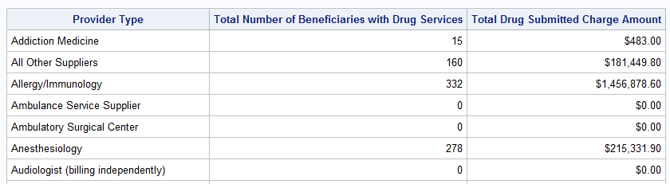

Paste your SAS code containing the `proc report` program into the file you submit. For this exercise, you do **not** need to copy and paste any results into the file you submit.

`proc report` can also produce totals and subtotals for summary-level variables using `break` and `rbreak` statements.

- `rbreak` (report break) is used to report summary statistics at the top or bottom of a report
- `break` is used to report summary statistics each time a group variable changes value

Let’s add the following line to the program above in which we calculated mean *Average Age of Beneficiaries* and *Average HCC Risk Score of Beneficiaries* by Provider Type. We’ll also add a `where` statement so that we can view a report of only a subset of the providers.

```
rbreak after/summarize;
```

If you scroll down to the bottom of the report, you will see an overall average calculated and displayed for both the numeric variables. The keyword `after` indicated to SAS that we wanted the break to occur after the report (we could alternatively have specified `before`). The option `summarize` indicated to SAS that we wanted the appropriate summary statistic printed after the break.

The `break` statement is similarly formatted, but requires that you specify the variable before or after which you would like the break to occur (this is specified before the `/`).

```
proc report data=L.cms_providers_la;
 where provider_type contains "Neuro";
 column provider_type beneficiary_average_age beneficiary_average_risk_score;
 define provider_type/display group "Provider Type";
 define beneficiary_average_age/analysis mean format=6.2;
 define beneficiary_average_risk_score/analysis mean format=6.2;
 rbreak after/summarize;
run;
```

**Exercise 6:**

Use `proc report` to generate the report displayed below (only the first 12 lines are displayed, but please generate the entire report). (Hint: you will probably want to use a `break` statement and the `group` option within two of your `define` statements).

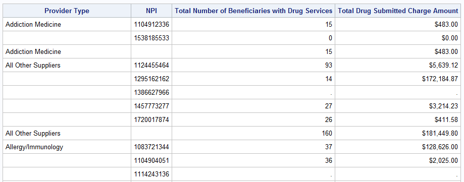

Paste your SAS code containing the `proc report` program into the file you submit. For this exercise, you do *not* need to copy and paste any results into the file you submit.

You are responsible for completing the 6 exercises described above and submitting them prior to 5:00PM on November 7th.